# SML201 Chapter 2.3

# Technical details related to concepts and functions covered in this chapter

We learnt in last chapter the different data types in R: integer, numeric, logical, character/string, factor and complex.

We also learnt two object types in R: vector and data frame. Recall that a data frame can have entries with different data types whereas a vector has to have homogeneous data type. It turns out that vectors and data frames are from different groups of objects in R.

**Two main classes of objects in R**:

- With homogeneous elements: Vectors, matrices, arrays.
- With heterogeneous elements: Lists, data frames.

## Examples of different R objects

**Vector**

Please see previous chapter for examples of vectors.

**Matrix– a “vector” with 2-dimensional shape**

```r
x2 = matrix(1:6, nrow = 3, ncol = 2)
class(x2)
[1] "matrix"
is.vector(x2)
[1] FALSE
# Prefix `is.` to any object type name will give you a
# function that checks whether the input is of the particular
# data type
is.data.frame(x2)
[1] FALSE
is.matrix(x2)
[1] TRUE
dim(x2)
[1] 3 2
length(x2)
[1] 6
```

**Array–a “vector” with 3 or more dimensional shape**

```r
x3 = array(1:24, c(2, 3, 4))
x3
, , 1

     [,1] [,2] [,3]
[1,]    1    3    5
[2,]    2    4    6

, , 2

     [,1] [,2] [,3]
[1,]    7    9   11
[2,]    8   10   12

, , 3

     [,1] [,2] [,3]
[1,]   13   15   17
[2,]   14   16   18

, , 4

     [,1] [,2] [,3]
[1,]   19   21   23
[2,]   20   22   24
# 4 blocks of matrices, each of size 2x3.
```

**List–can contains elements of *different* data types**

```r
mylist = list(elt1 = 3:9, elt2 = c(2.3, 1.5), elt3 = c("a", "zz"),
    elt4 = matrix(1:4, ncol = 2))
mylist  # you can have whatever you like for the elements on a list
$elt1
[1] 3 4 5 6 7 8 9

$elt2
[1] 2.3 1.5

$elt3
[1] "a"  "zz"

$elt4
     [,1] [,2]
[1,]    1    3
[2,]    2    4
class(mylist)
[1] "list"
```

**Data.frame–a special type of list which contains variables of the same number of rows**

```r
`?`(data.frame  # see the definition of a data.frame in the 'details' section
)

dat = data.frame(ind = 1:4, temperature = c(73.2, 75.6, 81.1,
    89), greater.than.86 = (c(73.2, 75.6, 81.1, 89) > 86), hot = c("No",
    "No", "No", "Yes"))
dat
```

| ind | temperature | greater.than.86 | hot |
| --- | --- | --- | --- |
| 1 | 73.2 | FALSE | No |
| 2 | 75.6 | FALSE | No |
| 3 | 81.1 | FALSE | No |
| 4 | 89.0 | TRUE | Yes |

```r
class(dat)
[1] "data.frame"
```

Often time data frames can be manipulated in similar ways as for matrices and lists. However, it is important to understand that data frame is a very different object type from matrix.

### Changing the data type of a vector

Note that for the three R objects above their elements always have the same data type. You can use the functions `as._data type_()` to change the data type of the elements in these R objects. Why do we want to change the data type of the elements in a R object? Having the appropriate data type allows R to extract the relevant information; e.g.,

```r
str(t.ship, strict.width = "cut")
'data.frame':   891 obs. of  12 variables:
 $ PassengerId: int  1 2 3 4 5 6 7 8 9 10 ...
 $ Survived   : int  0 1 1 1 0 0 0 0 1 1 ...
 $ Pclass     : int  3 1 3 1 3 3 1 3 3 2 ...
 $ Name       : Factor w/ 891 levels "Abbing, Mr. Anthony",....
 $ Sex        : Factor w/ 2 levels "female","male": 2 1 1 1 2..
 $ Age        : num  22 38 26 35 35 NA 54 2 27 14 ...
 $ SibSp      : int  1 1 0 1 0 0 0 3 0 1 ...
 $ Parch      : int  0 0 0 0 0 0 0 1 2 0 ...
 $ Ticket     : Factor w/ 681 levels "110152","110413",..: 52..
 $ Fare       : num  7.25 71.28 7.92 53.1 8.05 ...
 $ Cabin      : Factor w/ 148 levels "","A10","A14",..: 1 83 ..
 $ Embarked   : Factor w/ 4 levels "","C","Q","S": 4 2 4 4 4 ..
# currently `t.ship$Pclass` is an integer vector; thus when
# we apply the `summary()` function to `t.ship$Pclass` we
# have

summary(t.ship$Pclass)
   Min. 1st Qu.  Median    Mean 3rd Qu.    Max.
  1.000   2.000   3.000   2.309   3.000   3.000

# however, if we tell R that the elements in `t.ship$Pclass`
# actually represent categories we have

summary(as.factor(t.ship$Pclass))
  1   2   3
216 184 491
# which data type is more appropriate here?
```

We already talked about construction, concatenation, extraction and assignment for vectors and data frames; here we are going to talk about these techniques for other R objects.

### Construction, concatenation, extraction and assignment for some R objects

**Matrices**

You can create a matrix in R using the matrix function.

```r
m = matrix(1:6, nrow = 2, ncol = 3)
# By default matrices are fille by column in R.
m
     [,1] [,2] [,3]
[1,]    1    3    5
[2,]    2    4    6


m <- matrix(1:6, nrow = 2, ncol = 3, byrow = TRUE)
# You can change the assignment order by rows.
m
     [,1] [,2] [,3]
[1,]    1    2    3
[2,]    4    5    6
```

You can **assign** names to the rows and columns

```r
rownames(m) = c("r1", "r2")
colnames(m) = c("c1", "c2", "c3")
m
   c1 c2 c3
r1  1  2  3
r2  4  5  6
```

To **index** elements of a matrix, use the same **five methods of indexing that we have for vectors** but with the first index for rows and the second for columns.

```r
m[-1, 2]  # Exclusion and inclusion by position
[1] 5
m["r1", ]  # By name, also empty index means 'all'
c1 c2 c3
 1  2  3
m["r1", c("c1", "c2")]
c1 c2
 1  2
m[, c(T, T, F)]
   c1 c2
r1  1  2
r2  4  5
# Empty row index means taking all the rows logical column
# index (note: you will need to have the same number of index
# as the number of columns)

# What happens if we run
m[, c(T, F)]
   c1 c3
r1  1  3
r2  4  6
m
   c1 c2 c3
r1  1  2  3
r2  4  5  6
```

You can **combine** multiple matrices together

```r
m
   c1 c2 c3
r1  1  2  3
r2  4  5  6
m2 = matrix(11:16, ncol = 3)
m2
     [,1] [,2] [,3]
[1,]   11   13   15
[2,]   12   14   16

cbind(m, m2)  # combine 2 matrices side by side by columns
   c1 c2 c3
r1  1  2  3 11 13 15
r2  4  5  6 12 14 16

rbind(m, m2)  # stack 2 matrices by rows
   c1 c2 c3
r1  1  2  3
r2  4  5  6
   11 13 15
   12 14 16
```

Aside: To get more info on your matrix you can use these functions that you already leant for data frames:

```r
dim(m)  # The size of m
[1] 2 3
nrow(m)  # The number of rows in m
[1] 2
ncol(m)  # The number of columns in m
[1] 3
```

The functions above also can be used for data frames.

You can also take the transpose of your matrix this way

```r
t(m)  # Transpose of m
   r1 r2
c1  1  4
c2  2  5
c3  3  6
```

If you apply `t()` to a data frame `R` will coerce the data frame into a matrix first and you might get unexpected results.

**Array** – we can generalize the rules for vectors to arrays

An array is like a matrix, but with arbitrary dimension. The first argument is still a vector of elements to fill the array, but the second argument is a vector of sizes in each dimension

```r
ar = array(1:24, dim = c(2, 3, 4))  # A 3-D array
ar
, , 1

     [,1] [,2] [,3]
[1,]    1    3    5
[2,]    2    4    6

, , 2

     [,1] [,2] [,3]
[1,]    7    9   11
[2,]    8   10   12

, , 3

     [,1] [,2] [,3]
[1,]   13   15   17
[2,]   14   16   18

, , 4

     [,1] [,2] [,3]
[1,]   19   21   23
[2,]   20   22   24
ar[, , 1]  # extracting out the 1st block
     [,1] [,2] [,3]
[1,]    1    3    5
[2,]    2    4    6
ar
, , 1

     [,1] [,2] [,3]
[1,]    1    3    5
[2,]    2    4    6

, , 2

     [,1] [,2] [,3]
[1,]    7    9   11
[2,]    8   10   12

, , 3

     [,1] [,2] [,3]
[1,]   13   15   17
[2,]   14   16   18

, , 4

     [,1] [,2] [,3]
[1,]   19   21   23
[2,]   20   22   24
ar[2, , 3:4]  # extracting out the 2nd row of the 3rd and 4th block
     [,1] [,2]
[1,]   14   20
[2,]   16   22
[3,]   18   24
ar
, , 1

     [,1] [,2] [,3]
[1,]    1    3    5
[2,]    2    4    6

, , 2

     [,1] [,2] [,3]
[1,]    7    9   11
[2,]    8   10   12

, , 3

     [,1] [,2] [,3]
[1,]   13   15   17
[2,]   14   16   18

, , 4

     [,1] [,2] [,3]
[1,]   19   21   23
[2,]   20   22   24
ar[1:2, 2:3, 3:4]  # extracting out the first 2 rows and
, , 1

     [,1] [,2]
[1,]   15   17
[2,]   16   18

, , 2

     [,1] [,2]
[1,]   21   23
[2,]   22   24
# the 2nd and 3th columns of block 3 and 4
```

We will not use arrays much in this class.

**List and data frame**

In terms of *element data types* data frames and lists are in the same group. Recall that a data frame is just a special case of a list: all the elements on a data frame need to be of the same length while elements of a list can be of various length.

In terms of *structures* data frames and matrices are in the same group and vectors and lists are in another group.

Compare a data frame with a matrix: Both have a similar structure; however, the columns (i.e., the elements) of a data frame can have different data types whereas the columns of a matrix have to be of the same data type.

Similarly, vectors and lists have a similar structure; however, the elements of a list can have different data types whereas that of a vector have to be of the same data type.

```r
d = data.frame(let = c("a", "p"), val = 1:2, t = c(7.6, 5.1))

d
```

| let | val | t |
| --- | --- | --- |
| a | 1 | 7.6 |
| p | 2 | 5.1 |

```r
names(d)  # names of the elements of a data frame
[1] "let" "val" "t"
colnames(d)  # Remember that this also works for a matrix
[1] "let" "val" "t"
```

### Indexing, extraction and concatenation

**Data frame (this part is a review)**

You can index a data frame with all the ways that work for matrices. However, different extraction method might give you an output of different data type. In addition, you can extract a column by name using the $ symbol.

```r
class(d$val)  # a vector
[1] "integer"
class(d[[2]])  # a vector
[1] "integer"
class(d[, 2])  # a vector
[1] "integer"
class(d[2])  # a data frame
[1] "data.frame"

# Note that it makes sense to do this
class(d[2:3])
[1] "data.frame"
# but not this class(d[[2:3]]) see details here
# (https://cran.r-project.org/doc/manuals/R-lang.html#Indexing)
```

To combine multiple data frames we use the `data.frame()` function

```r
# create another data frame to combine with d
d2 = data.frame(let2 = c("k", "j"), val2 = 8:7)
d2
```

| let2 | val2 |
| --- | --- |
| k | 8 |
| j | 7 |

```r
# combine two data frames

data.frame(d, d2)
```

| let | val | t | let2 | val2 |
| --- | --- | --- | --- | --- |
| a | 1 | 7.6 | k | 8 |
| p | 2 | 5.1 | j | 7 |

```r
class(data.frame(d, d2))  # result is another data frame
[1] "data.frame"

cbind(d, d2)
```

| let | val | t | let2 | val2 |
| --- | --- | --- | --- | --- |
| a | 1 | 7.6 | k | 8 |
| p | 2 | 5.1 | j | 7 |

```r
class(cbind(d, d2))
[1] "data.frame"
```

**List**

```r
ingredients <- list(cheese = c("Cheddar", "Swiss", "Brie"), meat = c("Ham",
    "Turkey"))
ingredients
$cheese
[1] "Cheddar" "Swiss"   "Brie"

$meat
[1] "Ham"    "Turkey"

ingredients$meat  # Lists can be indexed by name, using $.
[1] "Ham"    "Turkey"
class(ingredients$meat)
[1] "character"
ingredients[2]
$meat
[1] "Ham"    "Turkey"
# can also be indexed like vectors, using [].  The result
# will be another list.
ingredients[[2]]
[1] "Ham"    "Turkey"
# can also extract individual elements of a list by using
# [[]]; recall the analogy of taking the R object out of a
# bag
```

To combine multiple lists we use the `c()` function

```r
ingredients2 = list(veggies = c("lettuce", "tomato"))

c(ingredients, ingredients2)
$cheese
[1] "Cheddar" "Swiss"   "Brie"

$meat
[1] "Ham"    "Turkey"

$veggies
[1] "lettuce" "tomato"

# What happens if you use `list()` instead?
list(ingredients, ingredients2)
[[1]]
[[1]]$cheese
[1] "Cheddar" "Swiss"   "Brie"

[[1]]$meat
[1] "Ham"    "Turkey"


[[2]]
[[2]]$veggies
[1] "lettuce" "tomato"
```

Let’s try out some exercises

```r
head(airquality, n = 8)
```

|  | Ozone | Solar.R | Wind | Temp | Month | Day |
| --- | --- | --- | --- | --- | --- | --- |
| 1 | 41 | 190 | 7.4 | 67 | 5 | 1 |
| 2 | 36 | 118 | 8.0 | 72 | 5 | 2 |
| 3 | 12 | 149 | 12.6 | 74 | 5 | 3 |
| 4 | 18 | 313 | 11.5 | 62 | 5 | 4 |
| 5 | NA | NA | 14.3 | 56 | 5 | 5 |
| 6 | 28 | NA | 14.9 | 66 | 5 | 6 |
| 7 | 23 | 299 | 8.6 | 65 | 5 | 7 |
| 8 | 19 | 99 | 13.8 | 59 | 5 | 8 |

```r
dim(airquality)
[1] 153   6
airquality[2, 3]
[1] 8
head(airquality$Wind)
[1]  7.4  8.0 12.6 11.5 14.3 14.9
head(airquality[, 3])  # same column of the dataset
[1]  7.4  8.0 12.6 11.5 14.3 14.9
# how many pairs of elements on these two vectors are
# unequal?
sum(airquality$Wind != airquality[, 3])
[1] 0
```

## Summary: The types of R object and how to index them:

```r
## Below are some examples; do not run them since you will
## need to create the objects for each of the types first

## Vectors: [index]
x[1:4]
x[-3]
x[x > 3]

## Matrices: [rowindex, colindex]
m[1, 2]
m[1:2, ]
m[, m[1, ] >= 2]
m["r1", ]
# here 'r1' is the row name for the first row of m

## Arrays: [index1, index2, ..., indexK]
a[1, 3, ]
a[a >= 6]

## Data frames: [rowindex, colindex], $name
cars$price
cars[, 3:4]
cars[cars$passengers == 5, ]

## Lists: $name, [index], [[index]]
ingredients$meat
ingredients[1:2]
ingredients[[1]]

## Note: both $ and [[]] can index only one element.
```

## Some built-in functions in R

Before talking about `tapply()` and `table()` we should get ourselves familiar with the data type `factor`. Factors in R are categorical variables.

For example, I have 8 patients, some of them are in a control group whereas other ones are in a treatment group. I can create a vector `grp` that gives the group labels of these patients.

```r
grp = factor(rep(c("Control", "Treatment"), each = 4))
```

```r
grp
[1] Control   Control   Control   Control   Treatment Treatment
[7] Treatment Treatment
Levels: Control Treatment
```

Now I know that the first 4 patients are in the control group and the last 4 are in the treatment group. Note that a factor vector is interpreted differently by R than a character vector; in our case `Control` and `Treatment` in `grp` are categories, not characters.

**tapply()**

The `tapply()` function allows us to apply a function to different parts of a vector, where the parts are indexed by a factor or a list of factors.

Single factor:

```r
effect = rnorm(8)  # Generate some fake data
effect
[1] -0.20147974  0.68241022 -0.07406566  1.09387582  1.84668806
[6]  1.87221596  0.99175187  0.11232323

`?`(tapply)
tapply(X = effect, INDEX = grp, FUN = mean)
  Control Treatment
0.3751852 1.2057448
# `X` is the vector that you want to apply `FUN` to; `INDEX`
# is the vector used to subset `X`
```

Multiple factors:

```r
sex = factor(rep(c("Female", "Male"), times = 4))
sex
[1] Female Male   Female Male   Female Male   Female Male
Levels: Female Male

tapply(effect, INDEX = list(grp, sex), FUN = mean)
              Female      Male
Control   -0.1377727 0.8881430
Treatment  1.4192200 0.9922696

# Here tapply evaluates mean(effect) on every group with
# unique combination of (grp, sex).
```

When using the `tapply()` function, you can include additional arguments for the function that you supply to `FUN` in the following way.

Let’s say that there are some NAs in the vector effect.

```r
effect.with.NAs = effect
effect.with.NAs[c(2, 5)] = NA
effect.with.NAs
[1] -0.20147974          NA -0.07406566  1.09387582          NA
[6]  1.87221596  0.99175187  0.11232323
```

This will just give us NA outputs because `R` does not know how we would want to deal with the `NA`s.

```r
tapply(effect.with.NAs, INDEX = grp, FUN = mean)
  Control Treatment
       NA        NA
```

Recall that `na.rm` is an input argument for `mean()`. We can set `na.rm = T` for `mean()` this way.

```r
tapply(effect.with.NAs, INDEX = grp, FUN = mean, na.rm = T)
  Control Treatment
0.2727768 0.9920970
```

The **table()** function uses the cross-classifying factors to build a contingency table of the counts at each combination of factor levels.

```r
grp
[1] Control   Control   Control   Control   Treatment Treatment
[7] Treatment Treatment
Levels: Control Treatment

table(grp)
grp
  Control Treatment
        4         4
# counts how many elements you have in each group
```

`table()` is just a special case of `tapply()`.

```r
tapply(rep(1, times = length(grp)), INDEX = grp, FUN = sum)
  Control Treatment
        4         4
# same result as above
```

**A word of caution**: the outputs of `table()` and `tapply()` are often arrays. However, a lot of functions often require their input arguments to be vectors. To convert an array into a vector we can use the `as.vector()` function. However, `as.vector()` strips the element names of its input by default. Therefore, we have to assign the names back to the vector. Here is an example

```r
grp.table = table(grp)
class(grp.table)
[1] "table"
`?`(table)
# an object of class 'table' is an array of integer values
grp.table
grp
  Control Treatment
        4         4
as.vector(grp.table)  # element names were
[1] 4 4
# stripped

v.grp.table = as.vector(grp.table)
# assign element names back to the vector
names(v.grp.table) = names(grp.table)
```

**`merge()`**

```r
# create data for the example
authors <- data.frame(surname = I(c("Tukey", "Venables", "Tierney",
    "Ripley", "McNeil")), nationality = c("US", "Australia",
    "US", "UK", "Australia"), deceased = c("yes", rep("no", 4)))

books <- data.frame(name = I(c("Tukey", "Venables", "Tierney",
    "Ripley", "Ripley", "McNeil", "R Core")), title = c("Exploratory Data Analysis",
    "Modern Applied Statistics ...", "LISP-STAT", "Spatial Statistics",
    "Stochastic Simulation", "Interactive Data Analysis", "An Introduction to R"),
    other.author = c(NA, "Ripley", NA, NA, NA, NA, "Venables & Smith"))
```

```r
authors
```

| surname | nationality | deceased |
| --- | --- | --- |
| Tukey | US | yes |
| Venables | Australia | no |
| Tierney | US | no |
| Ripley | UK | no |
| McNeil | Australia | no |

```r
books
```

| name | title | other.author |
| --- | --- | --- |
| Tukey | Exploratory Data Analysis | NA |
| Venables | Modern Applied Statistics ... | Ripley |
| Tierney | LISP-STAT | NA |
| Ripley | Spatial Statistics | NA |
| Ripley | Stochastic Simulation | NA |
| McNeil | Interactive Data Analysis | NA |
| R Core | An Introduction to R | Venables & Smith |

```r
# which data frame goes first if the variable for joining has
# different names the variable name in the data frame for the
# first input will be used Resulting data frame will have the
# overlap of `authors$surname` & `books$name`
authors.first = merge(x = authors, y = books, by.x = "surname",
    by.y = "name")

authors.first
```

| surname | nationality | deceased | title | other.author |
| --- | --- | --- | --- | --- |
| McNeil | Australia | no | Interactive Data Analysis | NA |
| Ripley | UK | no | Spatial Statistics | NA |
| Ripley | UK | no | Stochastic Simulation | NA |
| Tierney | US | no | LISP-STAT | NA |
| Tukey | US | yes | Exploratory Data Analysis | NA |
| Venables | Australia | no | Modern Applied Statistics ... | Ripley |

```r
books.first = merge(x = books, y = authors, by.y = "surname",
    by.x = "name")

books.first
```

| name | title | other.author | nationality | deceased |
| --- | --- | --- | --- | --- |
| McNeil | Interactive Data Analysis | NA | Australia | no |
| Ripley | Spatial Statistics | NA | UK | no |
| Ripley | Stochastic Simulation | NA | UK | no |
| Tierney | LISP-STAT | NA | US | no |
| Tukey | Exploratory Data Analysis | NA | US | yes |
| Venables | Modern Applied Statistics ... | Ripley | Australia | no |

```r
dim(authors)
[1] 5 3
dim(books)
[1] 7 3
```

```r
# check to see whether the names are in the same order note
# that the names are character vectors

sum(authors.first$surname != books.first$name)
[1] 0


# note that R Core was dropped since it is not in authors To
# include R Core, we can do a union-join
merge(x = authors, y = books, by.x = "surname", by.y = "name",
    all = TRUE)
```

| surname | nationality | deceased | title | other.author |
| --- | --- | --- | --- | --- |
| McNeil | Australia | no | Interactive Data Analysis | NA |
| R Core | NA | NA | An Introduction to R | Venables & Smith |
| Ripley | UK | no | Spatial Statistics | NA |
| Ripley | UK | no | Stochastic Simulation | NA |
| Tierney | US | no | LISP-STAT | NA |
| Tukey | US | yes | Exploratory Data Analysis | NA |
| Venables | Australia | no | Modern Applied Statistics ... | Ripley |

```r
# or do this: a right-join
merge(x = authors, y = books, by.x = "surname", by.y = "name",
    all.y = TRUE)
```

| surname | nationality | deceased | title | other.author |
| --- | --- | --- | --- | --- |
| McNeil | Australia | no | Interactive Data Analysis | NA |
| R Core | NA | NA | An Introduction to R | Venables & Smith |
| Ripley | UK | no | Spatial Statistics | NA |
| Ripley | UK | no | Stochastic Simulation | NA |
| Tierney | US | no | LISP-STAT | NA |
| Tukey | US | yes | Exploratory Data Analysis | NA |
| Venables | Australia | no | Modern Applied Statistics ... | Ripley |

**`mutate()`**

`mutate()` in the `dplyr` package adds new variables to the input of the function and preserves existing variables; `mutate()` is a convenient function to use when you want to add new columns to an existing data frame.

```r
# create variables to make a data frame
a = c("category I", "category II")
a
[1] "category I"  "category II"
m = matrix(1:6, ncol = 3)
m
     [,1] [,2] [,3]
[1,]    1    3    5
[2,]    2    4    6
```

```r
library("dplyr")
d = data.frame(a, m)
d
```

| a | X1 | X2 | X3 |
| --- | --- | --- | --- |
| category I | 1 | 3 | 5 |
| category II | 2 | 4 | 6 |

```r
# adding two new columns to d
new.d = mutate(d, X1minusX2 = X1 - X2, X2overX3 = X2/X3)
new.d
```

| a | X1 | X2 | X3 | X1minusX2 | X2overX3 |
| --- | --- | --- | --- | --- | --- |
| category I | 1 | 3 | 5 | -2 | 0.6000000 |
| category II | 2 | 4 | 6 | -2 | 0.6666667 |

```r
class(new.d)  #mutate preserve the object class
[1] "data.frame"
str(new.d)
'data.frame':   2 obs. of  6 variables:
 $ a        : Factor w/ 2 levels "category I","category II": 1 2
 $ X1       : int  1 2
 $ X2       : int  3 4
 $ X3       : int  5 6
 $ X1minusX2: int  -2 -2
 $ X2overX3 : num  0.6 0.667
```

This is the same as

```r
new.d2 = data.frame(d, X1minusX2 = d$X1 - d$X2, X2overX3 = d$X2/d$X3)
new.d2
```

| a | X1 | X2 | X3 | X1minusX2 | X2overX3 |
| --- | --- | --- | --- | --- | --- |
| category I | 1 | 3 | 5 | -2 | 0.6000000 |
| category II | 2 | 4 | 6 | -2 | 0.6666667 |

However, by default `data.frame()` will automatically convert all the character vector columns to factor vectors; thus, oftentimes it is better to use `mutate()` than `data.frame()`.

## using `boxplot()` on a matrix

The function `boxplot()` can be used on a matrix to make multiple boxplots, one for each column of a matrix. For example, here we have four columns of a matrix that list the sepal length and width and petal length and width, respectively, for 150 iris.

```r
flower.part.measurements = as.matrix(iris[, 1:4])
head(flower.part.measurements)
     Sepal.Length Sepal.Width Petal.Length Petal.Width
[1,]          5.1         3.5          1.4         0.2
[2,]          4.9         3.0          1.4         0.2
[3,]          4.7         3.2          1.3         0.2
[4,]          4.6         3.1          1.5         0.2
[5,]          5.0         3.6          1.4         0.2
[6,]          5.4         3.9          1.7         0.4
```

We can make four boxplots, one for each column of the matrix.

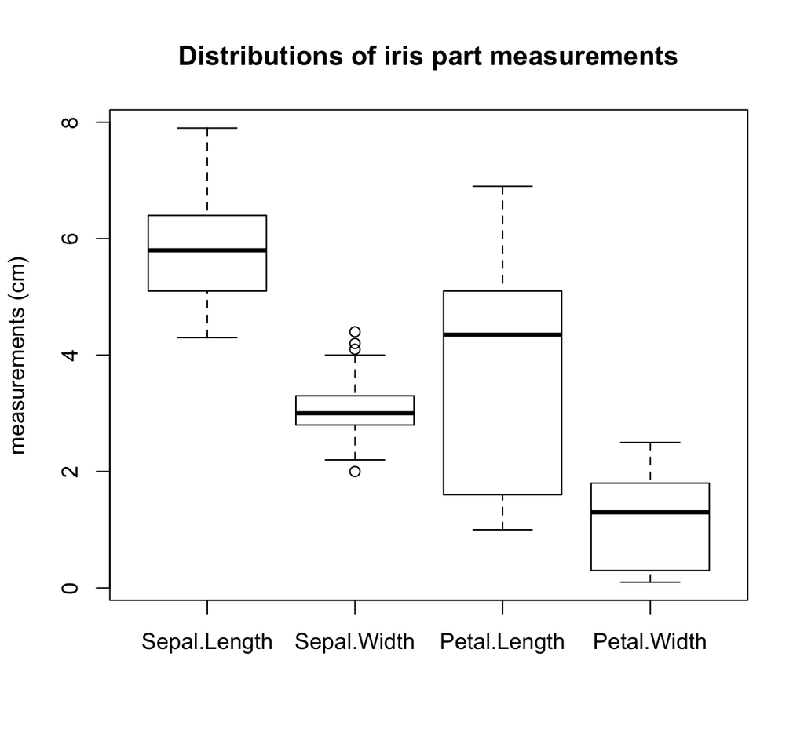

```r
boxplot(flower.part.measurements, ylab = "measurements (cm)",
    main = "Distributions of iris part measurements")
```

## Anatomy of a function

The syntax for writing a function is

> function(input_argument_list){body}
- The keyword `function` just tells R that you want to create a function.
- The arguments to a function are its inputs, which may have default values.
- Next we have the body of the function, which typically consists of expressions surrounded by curly brackets. Think of these as performing some operations on the input values given by the arguments.

Typically we assign the **function** to a particular **name**. This should describe what the function does.

> MyFunction = function(input_argument_list){body}

A function without a name is called an *orphan* function. These can be very powerfully used with the apply mechanism. Stay tuned….

```r
Square = function(x) {
    return(x^2)
}
```

the **body of the function**, which typically consists of expressions surrounded by curly brackets. Think of these as performing some operations on the input values given by the arguments.

> { expression 1  
> expression 2  
> return(value)  
> }

The **return** expression controls the values that you want to output. If the function returns more than one thing, this is done using a named list, for example return(list(total = sum(x), avg = mean(x))).

In the **absence of a return expression**, a function will return the last evaluated expression. This is particularly common if the function is short.

For example, I could write the simple function:

> MyMean = function(x) sum(x)/length(x)

Here I don’t even need brackets {}, since there is only one expression.

Below is another example of a function. This function extracts out the most popular name for a given year and a given gender.

```r
library(babynames)

popular.name = function(year, gender) {
    # year needs to be numeric `gender` need to be a character
    # vector of length one

    baby.year = babynames[babynames$year == year & babynames$sex ==
        gender, ]
    return(baby.year$name[baby.year$n == max(baby.year$n)])
}

popular.name(year = 2010, gender = "F")
[1] "Isabella"
```

A return expression anywhere in the function will cause the function to return control to the user immediately, without evaluating the rest of the function.

You will make a function to carry out these three steps for any data frame `d` in this week’s precept.

```r
dim(d)
class(d)
summary(d)
```